# Audit_Final_Exam_Presentation

Mughundhan Chandrasekar, Saai Krishnan Udayakumar, Amey Pophali, Sibi Senthur Muthusamy, Sidharth Varadharajan

4/27/2017

### **Creating an Environment**

We create a suitable environment for performing the required operations on the given data-sets by loading the required libraries before-hand. The data-sets that are required are also loaded during preliminary stage.

```r
rm(list=ls())
library(sqldf)
library(plyr)
library(readxl)
library(stringr)
library(lubridate)
library(benford.analysis)
library(pwr)
library(pps)
```

We create few functions for enhancing re-usability and efficiency of the project.

```r
importAccounts = function() {
  library(readxl, readr)
  path = "/Users/Mughundhan/UIC/UIC Academics/SPRING 2017/AUDIT/Final Presentation/Dataset" ## folder for files downloaded from UIC Blackboard
  files = c("arConfirmations.csv", "custCredit.csv", "empReimbursements.csv", "inventoryCounts.csv", "inventoryPerpetual.csv", "arCollections.csv", "purchases.csv", "sales.csv")
  dataFrameList = list()
  for(i in 1:length(files)){
    dataFrameName = strsplit(files[i], ".", fixed = TRUE)[[1]][1]
    fileType = strsplit(files[i], ".", fixed = TRUE)[[1]][2]
    if(fileType == "xlsx") {
      dataFrame = read_excel(paste(path, files[i], sep = "/"))
    } else {
      dataFrame = read.csv(paste(path, files[i], sep = "/"))
    }
    namedFrame = assign(dataFrameName, dataFrame)
    dataFrameList[[dataFrameName]] = namedFrame
  }
  return(dataFrameList)
}


convertAccounts = function(accounts) {
  library(stringr)
  library(lubridate)
  for(i in 1:length(accounts)) {
    for (n in 1:length(accounts[[i]])) {
      dataFrame = accounts[[i]]
      if(str_detect(names(dataFrame[n]), "date") | str_detect(names(dataFrame[n]), "dateColl")){
        if(is.factor(dataFrame[[n]])){
          accounts[[i]][[n]] = ymd(as.character(dataFrame[[n]]))
        }
      }
      else if(str_detect(names(dataFrame[n]), "sku") | str_detect(names(dataFrame[n]), "invoice")
              | str_detect(names(dataFrame[n]), ".no") | str_detect(names(dataFrame[n]), ".No")  | str_detect(names(dataFrame[n]), "customer")){
        accounts[[i]][[n]] = as.character(dataFrame[[n]])
      }
      else if (str_detect(names(dataFrame[n]), "cashtrue")) {
        accounts[[i]][[n]] = as.logical(dataFrame[[n]])
      }
      else if(str_detect(names(dataFrame[n]), "Amount")){
        accounts[[i]][[n]] = as.numeric(dataFrame[[n]])
      }
    }
  }
  return(accounts)
}


createCostofGoodsSold = function(accounts){
  costOfGoodsSold = merge(accounts$sales, accounts$inventoryPerpetual, by="sku", all.x=T)
  costOfGoodsSold$COGS = costOfGoodsSold$unitcost * costOfGoodsSold$qty
  accounts[["costOfGoodsSold"]] = costOfGoodsSold
  return(accounts)
}


createUnpaidAccountsReceivable = function(accounts) {
  splitSalesbyTransaction = split(accounts$sales, accounts$sales$cashtrue)
  credit = splitSalesbyTransaction[["FALSE"]]
  allCreditAccounts = merge(credit, accounts$arCollections, by="invoice", all.x = T)
  allCreditAccounts$notCollected = is.na(allCreditAccounts$amt.received)
  allCreditAccountsbyCollection = split(allCreditAccounts, allCreditAccounts$notCollect)
  unpaidAccountsReceivable = allCreditAccountsbyCollection[["TRUE"]]
  accounts[["unpaidAccountsReceivable"]] = unpaidAccountsReceivable
  return(accounts)
}



createAllowanceForDoubtfulAccounts = function(accounts) {
  x = accounts$unpaidAccountsReceivable
  endDateVector = rep(ymd("2016/12/31"), length(accounts$unpaidAccountsReceivable$invoice))
  x$endDate = endDateVector
  x$daysSincePurchase = x$endDate - x$date
  x$interval = findInterval(x$daysSincePurchase, c(90, 180))
  accounts[["doubtfulAccounts"]] = x
  return(accounts)
}



createOutofStock = function(accounts){
  salesBySKU = aggregate(qty~sku, accounts$sales,sum)
  purchasesBySKU = aggregate(quantity~sku,accounts$purchases,sum)
  purcahsesSalesBySKU = merge(salesBySKU, purchasesBySKU, by="sku")
  purchasesSalesInventoryBySKU = merge(purcahsesSalesBySKU, accounts$inventory, by="sku")
  purchasesSalesInventoryBySKU$turnover = (purchasesSalesInventoryBySKU$qtypurchasesSalesInventoryBySKU$quantity)/purchasesSalesInventoryBySKU$endstock
  turnover = data.frame(purchasesSalesInventoryBySKU$sku,purchasesSalesInventoryBySKU$turnover)
  colnames(turnover)=c("sku","times")
  accounts[["turnover"]] = turnover
  return(accounts)
}



createAccountsByYear = function(accounts, year) {
  for(i in 1:length(accounts)) {
    for (n in 1:length(accounts[[i]])) {
      dataFrame = accounts[[i]]
      dateColumnExists = FALSE
      if(str_detect(names(dataFrame[n]), "date") | str_detect(names(dataFrame[n]), "dateColl")){
        dateColumn = n
        dateColumnExists = TRUE
        break()
      }
    }
    if(dateColumnExists == TRUE) {
      accounts[[i]]$year = year(accounts[[i]][[dateColumn]])
      dataFramebyYear = split(accounts[[i]], accounts[[i]][["year"]])
      accounts[[i]] = dataFramebyYear[[year]]
    }
  }
  return(accounts)
}
```

```r
accounts = importAccounts()
accounts = convertAccounts(accounts)
accounts2016 = createAccountsByYear(accounts, year = "2016")
accounts2016 = createCostofGoodsSold(accounts2016)
accounts2016 = createUnpaidAccountsReceivable(accounts2016)
accounts2016 = createAllowanceForDoubtfulAccounts(accounts2016)
#head(accounts2016)
```

### Questions And Solutions

Now let us have a look at the solutions for the questions posted on Blackboard.

### **1.PLANNING AND RISK ASSESSMENT**

#### **Part 1: High Risk Accounts**

- For ease of understanding, we have displayed it in a tabular format.

```
##       RISKS                              IMPACT LIKELIHOOD RISK_FACTOR
##  [1,] "Cash"                             "5"    "7"        "35"
##  [2,] "Accounts Receivable"              "8"    "9"        "72"
##  [3,] "Inventory"                        "6"    "8"        "48"
##  [4,] "Fixed Assets"                     "8"    "4"        "32"
##  [5,] "Accounts Payable"                 "3"    "7"        "21"
##  [6,] "Cost of Goods Sold"               "8"    "5"        "40"
##  [7,] "Depreciation Expense"             "5"    "6"        "30"
##  [8,] "Sales Revenue (net)"              "7"    "8"        "56"
##  [9,] "Employee Expenses"                "9"    "7"        "63"
## [10,] "Allowances for Doubtful Accounts" "6"    "7"        "42"
```

- We considered the complete data set for the internal controls and substantive tests. This is because considering the complete dataset would enable us to audit the accounts precisely and efficiently. R Studio is a powerful tool that helped us take the whole dataset into account.

We also ran a t-test using pwr library and we got the random sample size values for account receivable audit and inventory audit. These are as follows -

[output not shown]

#### **2. TESTS OF INTERNAL CONTROLS**

#### **Part(1): Customers who exceeded their Credit Limit**

```r
findCreditNegatives = function(accounts) {
  library(plyr, dplyr)
  #Prepare Sales table
  sales = split(accounts$sales, accounts$sales$cashtrue)[["FALSE"]]
  sales = subset(sales, select = c(date, cust.no, total))
  names(sales)[names(sales) == "total"] = "trans"
  sales$trans = sales$trans*-1
  #Prepare Collections table
  collections = merge(accounts$sales, accounts$arCollections, by = "invoice", all.x = T)
  collections = na.omit(collections)
  collections = subset(collections, select = c(dateColl, cust.no.x, amt.received))
  names(collections)[names(collections) == "dateColl"] = "date"
  names(collections)[names(collections) == "amt.received"] = "trans"
  names(collections)[names(collections) == "cust.no.x"] = "cust.no"
  #TransactionsTable
  transTable = rbind(sales, collections)
  transTable = arrange(transTable, date)
  #Create TransByCustomer
  transByCustomer = split(transTable, transTable$cust.no)

  #Loop through customers
  badCreditAccount = data.frame()
  for(i in 1:length(transByCustomer)) {
    customer = transByCustomer[[i]]
    customerNumber = transByCustomer[[i]][1,]$cust.no
    customer$subTotal = accounts$custCredit[as.numeric(customerNumber),]$limit
    #loop through customer
    for(n in 1:length(customer$subTotal)) {
      if(n != 1) {
        customer[n,]$subTotal = customer[n - 1,]$subTotal + customer[n,]$trans
        if(sign(customer[n,]$subTotal) == -1) {
          badCreditAccount = rbind(badCreditAccount, customer[n,])
          break
        }
      }
    }
  }
  accounts[["overlimitCreditApprovals"]] = badCreditAccount
  return(accounts)
}
accounts2016 = findCreditNegatives(accounts2016)
#head(accounts2016$overlimitCreditApprovals)
```

[output not shown]

#### **Part (2.a): DUPLICATE TRANSACTIONS**

```r
findDuplicates = function(dataframe, column) {
  dataframe$test = as.numeric(dataframe[[column]])
  dataframe$dup = duplicated(dataframe$test)
  x = split(dataframe, dataframe$dup)
  y = x[["TRUE"]]
  print(y)
  print ("Duplicates (head)")
  head(y)
}
findDuplicates(dataframe = accounts2016$sales, column = "invoice")
```

```
## NULL
## [1] "Duplicates (head)"
```

#### **Part (2.b): OMITTED TRANSACTIONS**

```r
findMissingEntries =function(max,set) {
  good = 1:max
  test = as.numeric(set)
  missing = setdiff(good, set)
  print(missing)
  print ("Missing (head)")
  head(missing)
}
#head(findMissingEntries(max = length(accounts2016$sales$invoice), set = accounts2016$sales$invoice))
```

#### **Part (2.c): TRANSACTION CUT OFF TEST**

```r
findSalesNotIn2016 = function(accounts) {
  x = accounts$sales
  x$year = year(accounts$sales$date)
  y = split(x, x$year)
  z = rbind(y[["2015"]], y[["2017"]])
  print("Transactions not in 2016")
  print(z)
  print ("Transactions not in 2016 (head)")
  head(z)
}
#head(findSalesNotIn2016(accounts))
```

### **Question 3: RECOMPUTE THE TRIAL BALANCE**

#### **PART (0)**

```r
accountTotals = function(accounts) {

  #SALES REVENUE:
  print("Sales Revenue")
  totalSalesRevenue = sum(accounts$sales$total)
  print(totalSalesRevenue)

  #SALES RETURNS:
  print("Sales Returns")
  x = aggregate((returns)*unitprice ~ sku, accounts$inventoryPerpetual, sum)
  print(sum(x$`(returns) * unitprice`))

  #COGS:
  print("COGS")
  totalCOGS = sum(accounts$costOfGoodsSold$COGS)
  print(totalCOGS)

  #ACCOUNTS RECEIVABLE:
  print("Accounts Receivable")
  totalAR = sum(accounts$unpaidAccountsReceivable$total)
  print(sum(accounts$unpaidAccountsReceivable$total))

  #COLLECTIONS:
  print("Collections")
  totalCollections = sum(accounts$arCollections$amt.received)
  print(totalCollections)

  #INVENTORY:
  print("Inventory Perpetual on 1/1/2016")
  print(sum(accounts$inventoryPerpetual$beginstock))
  print("Inventory Perpetual on 12/31/2016")
  print(sum(accounts$inventoryPerpetual$endstock))
  print("Inventory Perpetual Cost on 1/1/2016")
  beginInventoryValue = sum(accounts$inventoryPerpetual$unitcost*accounts$inventoryPerpetual$beginstock)
  print(beginInventoryValue)
  print("Inventory Perpetual Cost on 12/31/2016")
  endInventoryValue = sum(accounts$inventoryPerpetual$unitcost*accounts$inventoryPerpetual$endstock)
  print(endInventoryValue)

  #PURCHASES:
  print("Purchases Cost")
  totalPurchasesCost = sum(accounts$purchases$unitcost*accounts$purchases$quantity)
  print(totalPurchasesCost)

  #EMPLOYEE REIMBURSEMENTS:
  print("Employee Reimbursements total")
  totalEmployeeReimbursements = sum(accounts$empReimbursements$Amount)
  print(totalEmployeeReimbursements)

}

accountTotals(accounts2016)
```

```
## [1] "Sales Revenue"
## [1] 960030574
## [1] "Sales Returns"
## [1] 2014072
## [1] "COGS"
## [1] 350802594
## [1] "Accounts Receivable"
## [1] 333286020
## [1] "Collections"
## [1] 650887909
## [1] "Inventory Perpetual on 1/1/2016"
## [1] 25086639
## [1] "Inventory Perpetual on 12/31/2016"
## [1] 25059323
## [1] "Inventory Perpetual Cost on 1/1/2016"
## [1] 151790200
## [1] "Inventory Perpetual Cost on 12/31/2016"
## [1] 152765109
## [1] "Purchases Cost"
## [1] 418576367
## [1] "Employee Reimbursements total"
## [1] 72750312
```

#### **PART (1.a): Foot(total)**

- For SALES Foot(total):

```
## [1] "Foot(total) of Sales"
```

```
## [1] 960030574
```

#### **PART (1.b): Statistical summary of the transactions in the datasets**

```r
summarizeAccount = function(accounts) {
  for(i in 1:length(accounts)){
    print(names(accounts[i]))
    print(summary(accounts[[i]]))
  }
}
summarizeAccount(accounts2016)
```

```
## [1] "arConfirmations"
##        X            invoice            cust.no           amt.received
##  Min.   :     4   Length:411248      Length:411248      Min.   : -129.0
##  1st Qu.:229246   Class :character   Class :character   1st Qu.:  246.2
##  Median :458039   Mode  :character   Mode  :character   Median :  629.3
##  Mean   :458228                                         Mean   :  991.4
##  3rd Qu.:687396                                         3rd Qu.: 1343.3
##  Max.   :916833                                         Max.   :15174.1
## [1] "custCredit"
##  customer.no            limit
##  Length:1000        Min.   :131000
##  Class :character   1st Qu.:268750
##  Mode  :character   Median :278000
##                     Mean   :276868
##                     3rd Qu.:286000
##                     Max.   :314000
## [1] "empReimbursements"
##   Receipt.No        Employee.No            Amount
##  Length:12428       Length:12428       Min.   :    1
##  Class :character   Class :character   1st Qu.: 2921
##  Mode  :character   Mode  :character   Median : 5860
##                                        Mean   : 5854
##                                        3rd Qu.: 8781
##                                        Max.   :11706
## [1] "inventoryCounts"
##      sku              defective         endstock        returns
##  Length:2000        Min.   :  55.0   Min.   : 5005   Min.   :  7.0
##  Class :character   1st Qu.: 156.8   1st Qu.: 8750   1st Qu.: 25.0
##  Mode  :character   Median : 226.0   Median :12632   Median : 42.0
##                     Mean   : 315.5   Mean   :12560   Mean   : 62.2
##                     3rd Qu.: 387.0   3rd Qu.:16335   3rd Qu.: 75.0
##                     Max.   :1825.0   Max.   :20112   Max.   :485.0
## [1] "inventoryPerpetual"
##        X              sku               unitcost        unitprice
##  Min.   :   1.0   Length:2000        Min.   : 0.000   Min.   : 0.000
##  1st Qu.: 500.8   Class :character   1st Qu.: 3.940   1st Qu.: 9.838
##  Median :1000.5   Mode  :character   Median : 5.965   Median :15.095
##  Mean   :1000.5                      Mean   : 6.061   Mean   :16.572
##  3rd Qu.:1500.2                      3rd Qu.: 8.070   3rd Qu.:22.260
##  Max.   :2000.0                      Max.   :15.710   Max.   :54.160
```

[output cut: 169 more lines]

```
## [1] "overlimitCreditApprovals"
##       date              cust.no              trans
##  Min.   :2016-04-13   Length:1000        Min.   :-11475.32
##  1st Qu.:2016-06-07   Class :character   1st Qu.: -3626.09
##  Median :2016-06-28   Mode  :character   Median : -2202.72
##  Mean   :2016-07-02                      Mean   : -2629.86
##  3rd Qu.:2016-07-23                      3rd Qu.: -1213.84
##  Max.   :2016-11-24                      Max.   :   -55.32
##     subTotal
##  Min.   :-8736.986
##  1st Qu.:-1487.470
##  Median : -726.845
##  Mean   :-1123.257
##  3rd Qu.: -302.742
##  Max.   :   -0.782
```

#### **PART (2): Range of dates of sales, purchases and collections**

```r
createDailySales = function(accounts) {
  totalSales = accounts$sales
  totalSales$amt = totalSales$qty * totalSales$unitprice
  dailySales = aggregate(amt~date,totalSales,sum)
  accounts[["dailySales"]] = dailySales
  return(accounts)
}


createDailyPurchases = function(accounts) {
  totalPurchases = accounts$purchases
  totalPurchases$amt = totalPurchases$quantity * totalPurchases$unitcost
  dailyPurchases = aggregate(amt~date,totalPurchases,sum)
  accounts[["dailyPurchases"]] = dailyPurchases
  return(accounts)
}


createDailyCollections= function(accounts) {
  totalCollections = accounts$arCollections
  dailyCollections = aggregate(amt.received~dateColl,totalCollections,sum)
  accounts[["dailyCollected"]] = dailyCollections
  return(accounts)
}
```

#### **PART (2.a): Compute the min max quartiles etc:**

#### **PART (2.b): Compute daily averages**

The above questions shall be solved in a simple way by calling the built-in R functions along with the reusable functions which we created. Since both the questions involves a similar approach, we are going to make use of an unified approach to solve the same (as shown below):

```r
accounts2016 = createDailySales(accounts2016)
summary(accounts2016$dailySales)
```

```
##       date                 amt
##  Min.   :2016-01-01   Min.   :1758475
##  1st Qu.:2016-04-01   1st Qu.:2022356
##  Median :2016-07-01   Median :2840832
##  Mean   :2016-07-01   Mean   :2623034
##  3rd Qu.:2016-09-30   3rd Qu.:2912291
##  Max.   :2016-12-31   Max.   :3098749
```

```r
accounts2016 = createDailyPurchases(accounts2016)
summary(accounts2016$dailyPurchases)
```

```
##       date                 amt
##  Min.   :2016-01-05   Min.   :34881364
##  1st Qu.:2016-03-25   1st Qu.:34881364
##  Median :2016-06-17   Median :34881364
##  Mean   :2016-06-17   Mean   :34881364
##  3rd Qu.:2016-09-08   3rd Qu.:34881364
##  Max.   :2016-12-02   Max.   :34881364
```

```r
accounts2016 = createDailyCollections(accounts2016)
summary(accounts2016$dailyCollected)
```

```
##     dateColl           amt.received
##  Min.   :2016-01-01   Min.   : 355863
##  1st Qu.:2016-04-01   1st Qu.:1360810
##  Median :2016-07-01   Median :1937318
##  Mean   :2016-07-01   Mean   :1778382
##  3rd Qu.:2016-09-30   3rd Qu.:2292952
##  Max.   :2016-12-31   Max.   :2555145
```

#### **PART (2.c): Do the ranges of dates of sales, purchases and collections lie within the fiscal year (2016) being audited?**

From the above, we shall infer that the Range falls within the fiscal year only if filtered data is passed else it doesnot happen.

#### **PART (2.d): If not, what corrections do you need to make to properly conduct the audit calculations you have made previously?**

If the range doesnot fall in the audit year, then apply year filter using **lubridate** feature

#### **PART (2.e): Would any of your computed account balances in the Trial Balance change because of your findings?**

Computed accounts would not change unless the non filtered data set is used.

### **Question 3: Employee Expenditure Audit**

#### Implementing Benford’s Law

```r
#Benford test
accounts2016$empReimbursements$Employee.No = as.integer(accounts2016$empReimbursements$Employee.No)
accounts2016$empReimbursements$Receipt.No = as.integer(accounts2016$empReimbursements$Receipt.No)

auditEmployeeReim = function(accounts) {
amtPerEmployee = aggregate(accounts$empReimbursements$Amount, by = list(accounts$empReimbursements$Employee.No), sum)
names(amtPerEmployee)[names(amtPerEmployee) == "Group.1"] = "employeeNumber"
names(amtPerEmployee)[names(amtPerEmployee) == "x"] = "Amount"
employeeAmt50000 = amtPerEmployee[which(amtPerEmployee$Amount>=50000),]
accounts[["employeeAmt50000"]] = employeeAmt50000
return(accounts)
}

accounts2016 = auditEmployeeReim(accounts2016)

print(head(accounts2016$employeeAmt50000))
```

```
##   employeeNumber Amount
## 1              0 719370
## 2              1 713562
## 3              2 630122
## 4              3 735776
## 5              4 740818
## 6              5 745801
```

- Inference: We can see that all the employees have exceeded the spending limit of 50000

```r
#Amount
benford_Emp_amount <- benford(accounts2016$empReimbursements$Amount,number.of.digits = 1, sign = "both", round = 3 )
benford_Emp_amount
```

```
##
## Benford object:
##
## Data: accounts2016$empReimbursements$Amount
## Number of observations used = 12428
## Number of obs. for second order = 11705
## First digits analysed = 1
##
## Mantissa:
##
##    Statistic Value
##         Mean  0.58
##          Var  0.11
##  Ex.Kurtosis -1.10
##     Skewness -0.54
##
##
## The 5 largest deviations:
##
##   digits absolute.diff
## 1      2       1003.46
## 2      1        764.20
## 3      9        624.33
## 4      8        546.28
## 5      7        468.28
##
## Stats:
##
##  Pearson's Chi-squared test
##
## data:  accounts2016$empReimbursements$Amount
## X-squared = 2345.9, df = 8, p-value < 2.2e-16
##
##
##  Mantissa Arc Test
##
## data:  accounts2016$empReimbursements$Amount
## L2 = 0.11869, df = 2, p-value < 2.2e-16
##
## Mean Absolute Deviation: 0.03892285
## Distortion Factor: 24.47812
##
## Remember: Real data will never conform perfectly to Benford's Law. You should not focus on p-values!
```

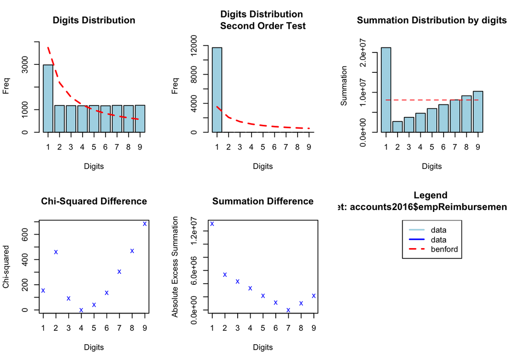

```r
plot(benford_Emp_amount)
```

```r
suspects_amount <- getSuspects(benford_Emp_amount, accounts2016$empReimbursement, how.many=2)
suspects_amount
```

```
##       Receipt.No Employee.No Amount
##    1:       3550          57   1283
##    2:       3551          27  11485
##    3:       3552          23  10400
##    4:       3555          28  10518
##    5:       3558          64   1259
##   ---
## 4158:      15951          39   1915
## 4159:      15953          89   1309
## 4160:      15958           8   1017
## 4161:      15960           1   2848
## 4162:      15962          56   1015
```

#### **Part (3): Predicted vs actual first digits in Receipt and Employee Number columns**

Plots are included in-order to enhance the understandability of the client.

```r
#Employee Number
benford_Emp_EmpNo <- benford(accounts2016$empReimbursements$Employee.No,number.of.digits = 1, sign = "both", round = 3 )
benford_Emp_EmpNo
```

```
##
## Benford object:
##
## Data: accounts2016$empReimbursements$Employee.No
## Number of observations used = 12302
## Number of obs. for second order = 98
## First digits analysed = 1
##
## Mantissa:
##
##    Statistic  Value
##         Mean  0.667
##          Var  0.068
##  Ex.Kurtosis -0.242
##     Skewness -0.809
##
##
## The 5 largest deviations:
##
##   digits absolute.diff
## 1      1       2362.27
## 2      2        819.27
## 3      9        784.09
## 4      8        720.72
## 5      7        665.58
##
## Stats:
##
##  Pearson's Chi-squared test
##
## data:  accounts2016$empReimbursements$Employee.No
## X-squared = 4902.7, df = 8, p-value < 2.2e-16
##
##
##  Mantissa Arc Test
##
## data:  accounts2016$empReimbursements$Employee.No
## L2 = 0.12099, df = 2, p-value < 2.2e-16
##
## Mean Absolute Deviation: 0.05962069
## Distortion Factor: 39.07338
##
## Remember: Real data will never conform perfectly to Benford's Law. You should not focus on p-values!
```

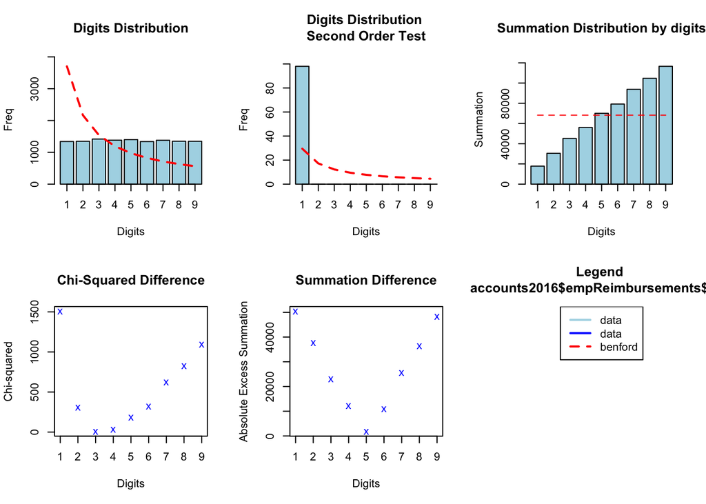

```r
plot(benford_Emp_EmpNo)
```

```r
suspects_employee <- getSuspects(benford_Emp_EmpNo, accounts2016$empReimbursement, how.many=2)
suspects_employee
```

```
##       Receipt.No Employee.No Amount
##    1:       3542          26   4131
##    2:       3551          27  11485
##    3:       3552          23  10400
##    4:       3554          13   5172
##    5:       3555          28  10518
##   ---
## 2684:      15930          18  11517
## 2685:      15935           2   4484
## 2686:      15955          20   5731
## 2687:      15960           1   2848
## 2688:      15966          20   6993
```

```r
#Receipts
benford_Emp_Receipts <- benford(accounts2016$empReimbursements$Receipt.No,number.of.digits = 1, sign = "both", round = 3 )
benford_Emp_Receipts
```

```
##
## Benford object:
##
## Data: accounts2016$empReimbursements$Receipt.No
## Number of observations used = 12428
## Number of obs. for second order = 12427
## First digits analysed = 1
##
## Mantissa:
##
##    Statistic  Value
##         Mean  0.475
##          Var  0.133
##  Ex.Kurtosis -1.756
##     Skewness  0.058
##
##
## The 5 largest deviations:
##
##   digits absolute.diff
## 1      1       2227.80
## 2      2       2188.46
## 3      3       1093.74
## 4      9        431.33
## 5      8        364.28
##
## Stats:
##
##  Pearson's Chi-squared test
##
## data:  accounts2016$empReimbursements$Receipt.No
## X-squared = 4998.5, df = 8, p-value < 2.2e-16
##
##
##  Mantissa Arc Test
##
## data:  accounts2016$empReimbursements$Receipt.No
## L2 = 0.25415, df = 2, p-value < 2.2e-16
##
## Mean Absolute Deviation: 0.06234307
## Distortion Factor: 5.974498
##
## Remember: Real data will never conform perfectly to Benford's Law. You should not focus on p-values!
```

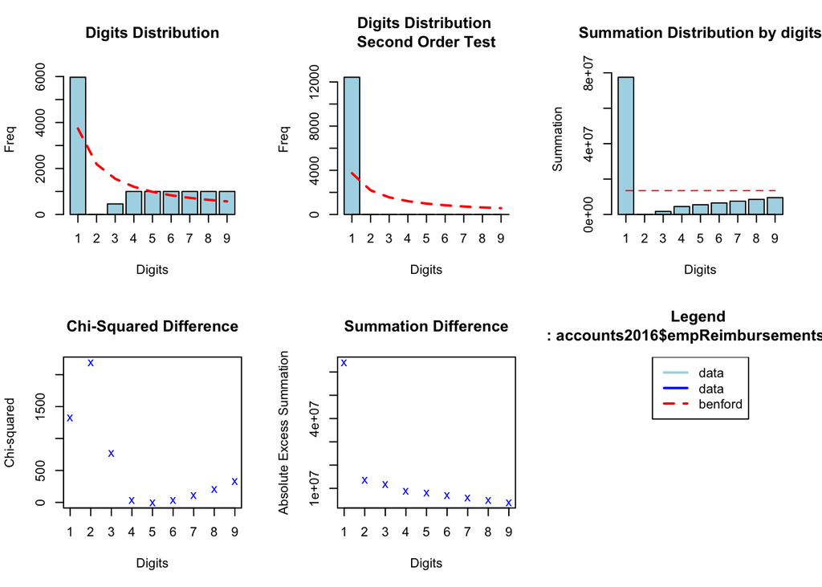

```r
plot(benford_Emp_Receipts)
```

#### **Part (4): Report any Suspicious findings:**

Suspicious findings are reported below:

```r
suspects <- getSuspects(benford_Emp_amount, accounts2016$empReimbursement, how.many=2)
suspects
```

```
##       Receipt.No Employee.No Amount
##    1:       3550          57   1283
##    2:       3551          27  11485
##    3:       3552          23  10400
##    4:       3555          28  10518
##    5:       3558          64   1259
##   ---
## 4158:      15951          39   1915
## 4159:      15953          89   1309
## 4160:      15958           8   1017
## 4161:      15960           1   2848
## 4162:      15962          56   1015
```

### **Question 4: Accounts Receivable Audit**

#### **Part (1): UNPAID ACCOUNTS RECEIVABLE**

```r
print("Unpaid Accounts Receivable")
```

```
## [1] "Unpaid Accounts Receivable"
```

```r
totalAR = sum(accounts2016$unpaidAccountsReceivable$total)
print(sum(accounts2016$unpaidAccountsReceivable$total))
```

```
## [1] 333286020
```

#### **Part (2): ALLOWANCE FOR DOUBTFUL ACCOUNTS**

```r
print("Uncollected Accounts Receivable")
```

```
## [1] "Uncollected Accounts Receivable"
```

```r
accounts2016 = createUnpaidAccountsReceivable(accounts2016)
print(sum(accounts2016$unpaidAccountsReceivable$total))
```

```
## [1] 333286020
```

```r
print("Allowance for Doubtful Accounts")
```

```
## [1] "Allowance for Doubtful Accounts"
```

```r
accounts2016 = createAllowanceForDoubtfulAccounts(accounts2016)
doubtfulTotals = aggregate(total~interval, accounts2016$doubtfulAccounts, sum)
print(0.3*doubtfulTotals$total[2] + 0.5*doubtfulTotals$total[3])
```

```
## [1] 58398058
```

#### **Part (4): SALES CUT OFF TEST**

```r
findSalesNotIn2016 = function(accounts) {
  x = accounts$sales
  x$year = year(accounts$sales$date)
  y = split(x, x$year)
  z = rbind(y[["2015"]], y[["2017"]])
  print("Transactions not in 2016")
  print(z)
  print ("Transactions not in 2016 (head)")
  head(z)
}
#head(findSalesNotIn2016(accounts))
```

#### **Part (6 a)**

```r
d=1000000/333286020
library(pwr)
pwr.t.test (n = NULL, d = 0.003, sig.level = 0.05, power = 0.8, type = "one.sample")
```

```
##
##      One-sample t test power calculation
##
##               n = 872097.5
##               d = 0.003
##       sig.level = 0.05
##           power = 0.8
##     alternative = two.sided
```

```r
mergeSalesAndARConfirmations = function(accounts) {
  allARAccounts = merge(accounts$arCollections, accounts$arConfirmations, by="invoice", all.x = T)
  allARAccounts = subset(allARAccounts, select = c(invoice, amt.received.x, amt.received.y))
  allARAccounts = na.omit(allARAccounts)
  accounts[["allARConfirmationsAndCollections"]] = allARAccounts
  return(accounts)
}
accounts2016 = mergeSalesAndARConfirmations(accounts2016)
```

#### **Part (6 b):**

The Percentage Error is given below:

```r
sampleConfirmation = accounts2016$allARConfirmationsAndCollections[ppss(accounts2016$allARConfirmationsAndCollection$amt.received.y, 1483718),]
distinctSampleConfirmation = unique(sampleConfirmation)
difference = sum(distinctSampleConfirmation$amt.received.y - distinctSampleConfirmation$amt.received.x)
totalConfirmedAmounts = sum(distinctSampleConfirmation$amt.received.y)
percentageError = (difference/totalConfirmedAmounts)*100
percentageError
```

```
## [1] 0.02962628
```

#### **Part (7):**

- The error percentage i.e. percentage change in audited value against the recorded values is observed to be around 0.029% percent.
- Since the error is too negligible we can consider it to be more or less accurate

### **Question 5: Inventory Audit**

#### **Part 1:**

The total cost of Goods sold is accounted for the year 2016 and is given below:

```r
accounts2016 = createCostofGoodsSold(accounts2016)
sum(accounts2016$costOfGoodsSold$COGS)
```

```
## [1] 350802594
```

#### **Part 1 a:**

- The accounting principle which is important in accurately making this calculation is the **Matching Principle**. In accrual accounting, the matching principle states that expenses should be recorded during the period in which they are incurred, regardless of when the transfer of cash occurs.

#### **Part 2 a:**

The detailed summary of the MarkUp percentages (Max, Min, Quartiles) are computed and shown below:

```
##    Min. 1st Qu.  Median    Mean 3rd Qu.    Max.    NA's
##   0.503   1.078   1.745   1.739   2.374   3.000   11004
```

#### **Part 3 a: Stocked out**

```r
findOutOfStockDemand = function(accounts) {
  library(plyr)
  #prepare tables
  sales = subset(accounts$sales, select = c(sku, date, qty))
  sales$qty = sales$qty*-1

  purchases = accounts$purchases
  purchases$qty = purchases$quantity
  purchases = subset(purchases, select = c(sku, date, qty))

  inventoryTrans = rbind(sales, purchases)
  inventoryTrans = arrange(inventoryTrans, date)

  #Create dataframe by sku
  inventoryTransBySku = split(inventoryTrans, inventoryTrans$sku)

  stockOutSkus = list()
  for(i in 1:length(inventoryTransBySku)) {
    sku = inventoryTransBySku[[i]]
    skuNumber = as.numeric(sku[1,]$sku)
    sku$onHand = accounts$inventoryPerpetual[skuNumber,]$beginstock

    for(n in 1:length(sku$qty)) {
      if(n == 1) {
        sku[n,]$onHand = sku[n,]$onHand + sku[n,]$qty
      }
      else {
        sku[n,]$onHand = sku[n-1,]$onHand + sku[n,]$qty
      }
    }
    if(sum(sku$onHand < 0) > 0) {
      stockOutSkus[[length(stockOutSkus) + 1]] = skuNumber
    }
    inventoryTransBySku[[i]] = sku
  }
  stockOutTrans = data.frame()
  for(i in 1:length(stockOutSkus)){
    skuNumber = stockOutSkus[[i]]
    sku = inventoryTransBySku[[as.character(skuNumber)]]
    times = which(diff(sign(sku$onHand)) > 0)
    for(n in 1:length(times)) {
      stockOutTrans = rbind(stockOutTrans, sku[times[n],])
    }
  }
  accounts[["stockOutTrans"]] = stockOutTrans
  return(accounts)
}
accounts2016 = findOutOfStockDemand(accounts2016)
accounts2016$stockOutTrans = na.omit(accounts2016$stockOutTrans)
head(accounts2016$stockOutTrans$sku)
```

```
## [1] "1084" "1084" "1095" "1124" "1230" "1230"
```

#### **Part 4(a)**

```r
d=1000000/152765109
d
```

```
## [1] 0.006545997
```

```r
library(pwr)
pwr.t.test (n = NULL, d = 0.0065, sig.level = 0.05, power = 0.8, type = "one.sample")
```

```
##
##      One-sample t test power calculation
##
##               n = 185773.8
##               d = 0.0065
##       sig.level = 0.05
##           power = 0.8
##     alternative = two.sided
```

```r
mergeInventoryPerpetualAndCounts = function(accounts) {
  allInventory = merge(accounts$inventoryPerpetual, accounts$inventoryCounts, by="sku", all.x = T)
  allInventory = subset(allInventory, select = c(sku, beginstock,endstock.x, endstock.y,unitcost,defective.y,returns.y))
  allInventory = na.omit(allInventory)
  accounts[["allInventoryMatched"]] = allInventory
  return(accounts)
}
accounts2016 = mergeInventoryPerpetualAndCounts(accounts2016)
```

#### **Part (4 b):**

The **Percentage Error** is computed and displayed below:

```r
sampleConfirmation = accounts2016$allInventoryMatched[ppss(accounts2016$allInventoryMatched$endstock.y, 185774),]
distinctSampleConfirmation = unique(sampleConfirmation)
sum(distinctSampleConfirmation$endstock.x)
```

```
## [1] 25059323
```

```r
difference = sum(distinctSampleConfirmation$endstock.y - distinctSampleConfirmation$endstock.x)
totalConfirmedAmounts = sum(distinctSampleConfirmation$endstock.y)
percentageError = (difference/totalConfirmedAmounts)*100
percentageError
```

```
## [1] 0.241898
```

#### **Part 5: Foot total(inventory accounts balance -> endstock x unitprice)**

```r
totalInventoryBalanceAfterAdjusting = sum(accounts2016$allInventoryMatched$endstock.y*accounts2016$allInventoryMatched$unitcost)
totalInventoryBalanceAfterAdjusting
```

```
## [1] 153129104
```

#### **Part 6 : Ageing of Inventory**

The aged inventory total is computed and given as follows:

```r
createInventoryAgeingData = function(accounts){
  inventoryAgeing = merge(accounts$sales, accounts$allInventoryMatched, by="sku", all.x=T)
  inventoryAgeing = subset(inventoryAgeing, select = c(sku, date, qty,unitcost,beginstock,endstock.y,total))
  inventoryAgeing$COGS = inventoryAgeing$unitcost * inventoryAgeing$qty
  inventoryAgeing$AvgInvCost = ((inventoryAgeing$endstock.y + inventoryAgeing$beginstock)* inventoryAgeing$unitcost / 2)
  inventoryAgeing$turnover = inventoryAgeing$COGS/inventoryAgeing$AvgInvCost
  accounts[["inventoryAgeing"]] = inventoryAgeing
  return(accounts)
}
accounts2016 = createInventoryAgeingData(accounts2016)
names(accounts2016$inventoryAgeing)[names(accounts2016$inventoryAgeing) == "endstock.y"] = "endstock"

createInventoryAgeingFinal = function(accounts){
  accountsInventoryAgeingSorted=accounts$inventoryAgeing
  accountsInventoryAgeingSortedFiltered = sqldf("Select sku, sum(qty) as qty,unitcost,endstock,AvgInvCost from accountsInventoryAgeingSorted group by sku")
  accountsInventoryAgeingSortedFiltered$COGS = accountsInventoryAgeingSortedFiltered$qty*accountsInventoryAgeingSortedFiltered$unitcost
  accountsInventoryAgeingSortedFiltered$turnOverRatio = accountsInventoryAgeingSortedFiltered$COGS/accountsInventoryAgeingSortedFiltered$AvgInvCost
  #accountsInventoryAgeingSortedFiltered = accountsInventoryAgeingSortedFiltered[!(accountsInventoryAgeingSortedFiltered$turnOverRatio==0),]
  accountsInventoryAgeingSortedFiltered$age = 365 / accountsInventoryAgeingSortedFiltered$turnOverRatio
  accounts[["inventoryAgeingFinal"]] = accountsInventoryAgeingSortedFiltered
  return(accounts)
}
accounts2016 = createInventoryAgeingFinal(accounts2016)
accounts2016_backup = accounts2016

#head(accounts2016$inventoryAgeingFinal)
effectiveCostUnderSixty=0
effectiveCostOverSixtyLessOneEighty=0
effectiveCostOver180Less365=0
effectiveCostOver365=0
i=as.integer()
accounts2016$inventoryAgeingFinal$age = as.numeric(accounts2016$inventoryAgeingFinal$age)
#na.omit(accounts2016$inventoryAgeingFinal)

inventoryAgeingCheckData = accounts2016$inventoryAgeingFinal
#inventoryAgeingCheckData[complete.cases(inventoryAgeingCheckData),]


for (i in 1:2000){
  #print(i)
  #print(accounts2016$inventoryAgeingFinal$age[i])
  if(is.na(accounts2016$inventoryAgeingFinal$age[i])){
    next
  }
  if(accounts2016$inventoryAgeingFinal$age[i] < 60){
    effectiveCostUnderSixty = effectiveCostUnderSixty + (accounts2016$inventoryAgeingFinal$unitcost[i]*accounts2016$inventoryAgeingFinal$endstock[i])
  }else
    if(accounts2016$inventoryAgeingFinal$age[i]>=60 && accounts2016$inventoryAgeingFinal$age[i]<180){
      effectiveCostOverSixtyLessOneEighty = effectiveCostOverSixtyLessOneEighty + (0.50)*(accounts2016$inventoryAgeingFinal$unitcost[i]*accounts2016$inventoryAgeingFinal$endstock[i])
    }else
      if(accounts2016$inventoryAgeingFinal$age[i]>=180 && accounts2016$inventoryAgeingFinal$age[i]<365){
        effectiveCostOver180Less365 = effectiveCostOver180Less365 + (accounts2016$inventoryAgeingFinal$unitcost[i]*accounts2016$inventoryAgeingFinal$endstock[i])
      }else{
        effectiveCostOver365 = effectiveCostOver365 + (accounts2016$inventoryAgeingFinal$unitcost[i]*accounts2016$inventoryAgeingFinal$endstock[i])
      }
}

agedInventoryTotal = effectiveCostUnderSixty + effectiveCostOverSixtyLessOneEighty + effectiveCostOver180Less365 + effectiveCostOver365
agedInventoryTotal
```

```
## [1] 106273976
```

The computed value for **effectiveCostUnderSixty** is given below:

```r
effectiveCostUnderSixty
```

```
## [1] 0
```

The computed value for **effectiveCostOverSixtyLessOneEighty** is given below:

```r
effectiveCostOverSixtyLessOneEighty
```

```
## [1] 46855128
```

The computed value for **effectiveCostOver180Less365** is given below:

```r
effectiveCostOver180Less365
```

```
## [1] 59418847
```

The computed value for **effectiveCostOver365** is given below:

```r
effectiveCostOver365
```

```
## [1] 0
```

#### **Part 6 a**

The Percentage of total less than 60

```r
percentageOfTotalLess60 = (effectiveCostUnderSixty/agedInventoryTotal)*100
percentageOfTotalLess60
```

```
## [1] 0
```

#### **Part 6 b**

The Percentage of total computed for the range between 60 and 180

```r
percentageOfTotalOver60Less180 = (effectiveCostOverSixtyLessOneEighty/agedInventoryTotal)*100
percentageOfTotalOver60Less180
```

```
## [1] 44.089
```

#### **Part 6 c**

The Percentage of total computed for the range between 180 and 365

```r
percentageOfTotalOver180Less365 = (effectiveCostOver180Less365/agedInventoryTotal)*100
percentageOfTotalOver180Less365
```

```
## [1] 55.911
```

#### **Part 6 d**

The Percentage of total computed for the range above 365

```r
percentageOfTotalOver365 = (effectiveCostOver365/agedInventoryTotal)*100
percentageOfTotalOver365
```

```
## [1] 0
```

#### **Part 7:**

```r
counter=0
for(i in 1:2000){
  if(is.na(accounts2016$inventoryAgeingFinal$COGS[i])){
    print("NA")
    print(i)
    print("NA")
    next
  }
if((accounts2016$inventoryAgeingFinal$COGS[i]/accounts2016$inventoryAgeingFinal$endstock[i]) < 10){
    print(accounts2016$inventoryAgeingFinal$sku[i])
    counter=counter+1
}
}
counter
```

```
## [1] 629
```

#### **Part 8: Market Test Inventory**

```r
marketTestInventory = function(accounts)
{
  inventoryPerpMarketTest = subset(accounts$inventoryPerpetual, select = c(sku, unitprice, unitcost))
  InventoryMarketTest = merge(accounts$inventoryCounts,inventoryPerpMarketTest,by="sku")
  InventoryMarketTest$diff = (InventoryMarketTest$unitprice-InventoryMarketTest$unitcost) * InventoryMarketTest$endstock
  accounts[["InventoryMarketTest"]] = InventoryMarketTest
  return(accounts)
}

accounts2016 = marketTestInventory(accounts2016)

#print(head(accounts2016$InventoryMarketTest[InventoryMarketTest$diff < 0,]))
#NULL
```

#### **Part 9 and 10 (Preface)**

```r
salesInventoryMerge = merge(accounts2016$sales,accounts2016$allInventoryMatched,by="sku")
aggregateQuantity=aggregate(salesInventoryMerge$qty,by=list(salesInventoryMerge$sku),sum)
names(aggregateQuantity)[names(aggregateQuantity) == "Group.1"] = "sku"
names(aggregateQuantity)[names(aggregateQuantity) == "x"] = "qty"
head(salesInventoryMerge)
```

```
##   sku      X invoice qty cashtrue       date unitprice total cust.no year
## 1   1 505903  505903   4     TRUE 2016-10-12       5.7  22.8     373 2016
## 2   1 278696  278696 122    FALSE 2016-08-02       5.7 695.4     606 2016
## 3   1 962588  962588  12    FALSE 2016-07-22       5.7  68.4     106 2016
## 4   1 454907  454907   2    FALSE 2016-05-24       5.7  11.4     882 2016
## 5   1 688592  688592  39    FALSE 2016-12-25       5.7 222.3     427 2016
## 6   1 917373  917373 104    FALSE 2016-06-18       5.7 592.8     527 2016
##   beginstock endstock.x endstock.y unitcost defective.y returns.y
## 1       6714      12175      12344     3.73         100        12
## 2       6714      12175      12344     3.73         100        12
## 3       6714      12175      12344     3.73         100        12
## 4       6714      12175      12344     3.73         100        12
## 5       6714      12175      12344     3.73         100        12
## 6       6714      12175      12344     3.73         100        12
```

```r
head(aggregateQuantity)
```

```
##    sku   qty
## 1    1 14338
## 2   10 30161
## 3  100 25475
## 4 1000 29117
## 5 1001 28488
## 6 1002 27687
```

```r
salesInventoryMerge = merge(salesInventoryMerge[,c('sku','unitprice','unitcost','beginstock','endstock.y')],aggregateQuantity,by="sku")
salesInventoryMerge=unique((salesInventoryMerge))
head(salesInventoryMerge)
```

```
##       sku unitprice unitcost beginstock endstock.y   qty
## 1       1      5.70     3.73       6714      12344 14338
## 283    10      3.32     1.88      13325      11346 30161
## 838   100     19.00     8.07       5341       9374 25475
## 1358 1000     17.23     8.29      17136      16128 29117
## 1912 1001     21.77     5.62      16363       8068 28488
## 2422 1002     23.19     8.78      19098      10995 27687
```

#### **Part 9:**

- Nrv < cost where NRV = unitprice - costprice - otherexpenses(which is zero in this case)

```r
counter=0
for(i in 1:2000){
  if(is.na(salesInventoryMerge$unitprice[i]) | is.na(salesInventoryMerge$unitcost[i])){
    print("NA")
    print(i)
    print("NA")
    next
  }
  if((salesInventoryMerge$unitprice[i]-(salesInventoryMerge$unitcost[i])) < salesInventoryMerge$unitcost[i]){
    print(salesInventoryMerge$sku[i])
    counter=counter+1
  }
}
counter
```

```
## [1] 433
```

- Inference: We arrive at the conclusion that, **433 inventory items** have Net Realizable value less than cost.

#### **Part 10:**

- NRV < 110% of cost where NRV = unitprice - costprice - otherexpenses(which is salescommission=10% of unitcost)

```r
counter=0
for(i in 1:2000){
  if(is.na(salesInventoryMerge$unitprice[i]) | is.na(salesInventoryMerge$unitcost[i])){
    print("NA")
    print(i)
    print("NA")
    next
  }
  if((salesInventoryMerge$unitprice[i] - salesInventoryMerge$unitcost[i] - (0.1 * salesInventoryMerge$unitcost[i])) < (1.1 * salesInventoryMerge$unitcost[i])){
    print(salesInventoryMerge$sku[i])
    counter=counter+1
  }
}
counter
```

```
## [1] 587
```

- Inference: We arrive at the conclusion that, **587 inventory items** have Net Realizable value less than 110% of the cost and Sales Commission that are 10% of cost.

**Notes for Questions 5 - Part 9 and 10**

- If this calculation does result in a loss, you should charge the loss to the cost of goods sold expense with a debit, and credit the #inventory account to reduce the value of the inventory account. If the loss is material, you may want to segregate it in a separate #loss account, which more easily draws the attention of a reader of a company’s financial statements.
- Net realizable value is actually only one of the factors you consider in determining the lower of cost or market, so see the Lower of #Cost or Market article for a complete explanation.
- Net realizable value can also refer to the aggregate total of the ending balances in the trade accounts receivable account and the #offsetting allowance for doubtful accounts. This net amount represents the amount of cash that management expects to realize once it #collects all outstanding accounts receivable.

#### **Part 11 and 12**

```r
purchasePerSKU = arrange(accounts2016$purchases,accounts2016$purchases$sku)
purchasePerSKU = subset(purchasePerSKU, select = c(sku, quantity))
purchasePerSKU = aggregate(purchasePerSKU$quantity,by=list(purchasePerSKU$sku),sum)
names(purchasePerSKU)[names(purchasePerSKU) == "Group.1"] = "sku"
names(purchasePerSKU)[names(purchasePerSKU) == "x"] = "quantity"
#purchasePerSKU
mergedPurchaseAndInventory = merge(purchasePerSKU,accounts2016$allInventoryMatched,by="sku")
mergedPurchaseAndInventory = subset(mergedPurchaseAndInventory, select = c(sku,quantity,beginstock,returns.y,defective.y))
mergedPurchaseAndInventory$defectiveRate = (mergedPurchaseAndInventory$defective.y / (mergedPurchaseAndInventory$quantity))*100
sum(mergedPurchaseAndInventory$defectiveRate > 1)
```

```
## [1] 566
```

```r
mergedPurchaseAndInventory$returnRate = (mergedPurchaseAndInventory$returns.y / (mergedPurchaseAndInventory$quantity))*100
sum(mergedPurchaseAndInventory$returnRate > 1)
```

```
## [1] 15
```

```r
salesPerSKU = aggregate(accounts2016$sales$qty,by=list(accounts2016$sales$sku),sum)
names(salesPerSKU)[names(salesPerSKU) == "Group.1"] = "sku"
names(salesPerSKU)[names(salesPerSKU) == "x"] = "quantity"
mergedSalesAndInventory = merge(salesPerSKU,accounts2016$allInventoryMatched,by="sku")
mergedSalesAndInventory = subset(mergedSalesAndInventory, select = c(sku,quantity,beginstock,returns.y,defective.y))
mergedSalesAndInventory$defectiveRate = (mergedSalesAndInventory$defective.y / (mergedSalesAndInventory$quantity))*100
sum(mergedSalesAndInventory$defectiveRate > 1)
```

```
## [1] 724
```

```r
mergedSalesAndInventory$returnRate = (mergedSalesAndInventory$returns.y / (mergedSalesAndInventory$quantity))*100
sum(mergedSalesAndInventory$returnRate > 2)
```

```
## [1] 0
```